# Homework Assignment 1

Alexander Reiner

Assigned: Oct 24, 2020, Due Sun Nov 01, 2020 11:59PM

```r
# Data Manipulation
nyc <- read.csv("nycflights.csv")

# Delete the column named "X"
nyc$X <- NULL

#Recode columns as factors as needed
nyc$carrier <- as.factor(nyc$carrier)
nyc$flight <- as.factor(nyc$flight)
nyc$tailnum <- as.factor(nyc$tailnum)
nyc$origin <- as.factor(nyc$origin)
nyc$dest <- as.factor(nyc$dest)

#Add airgain column
nyc$airgain <- c(nyc$dep_delay - nyc$arr_delay)
```

# Data Exploration

### How Many Airlines are there?

```r
# use length and levels function
length(levels(nyc$carrier))
```

[output not shown]

There are 16 airlines

### How many flights there were by the airline code oo?

```r
# Use nrow
nrow(nyc[nyc$carrier == "OO",])
```

[output not shown]

There are 32 flights from airline code OO.

### How long is the shortest flight out of any NYC airport?

```r
# Use min function

min(nyc$air_time, na.rm = TRUE)
```

[output not shown]

The shortest flight out of any NYC airport is 20 minutes.

### How many flights were there by United Airlies on January 12th 2013?

```r
#Use nrow

nrow(nyc[nyc$carrier == "UA" & nyc$year == 2013 & nyc$month == 1 & nyc$day ==12, ])
```

```
## [1] 112
```

On January 12, 2013, there were 112 flights by United Airlines.

# Arrival Delay

### What was the average arrival delay for all airports and all airlines combined in January 2013?

```r
# Use mean function
jan2013 <- nyc[nyc$month == 1, ]

mean(jan2013$arr_delay, na.rm=TRUE)
```

```
## [1] 6.129972
```

The average arrival delay for all airports and airlines in January 2013 is 6.129972 minutes.

### What was the median arrival delay for all airports and all airlines combined in January 2013?

```r
median(jan2013$arr_delay, na.rm = TRUE)
```

[output not shown]

The median arrival delay for all airports and airlines in January 2013 is -3 minutes.

# Airline Performance

### Average Arrival Delay by Airline

```r
# Use function tapply

arr_delay_by_airline <- round(tapply(nyc$arr_delay, nyc$carrier, mean,  na.rm=TRUE), 2)

arr_delay_by_airline
```

```
##    9E    AA    AS    B6    DL    EV    F9    FL    HA    MQ    OO    UA    US
##  7.38  0.36 -9.93  9.46  1.64 15.80 21.92 20.12 -6.92 10.77 11.93  3.56  2.13
##    VX    WN    YV
##  1.76  9.65 15.56
```

### Arrival Delay Barplot

```r
library(RColorBrewer)
color <- brewer.pal(16, "Set1")
```

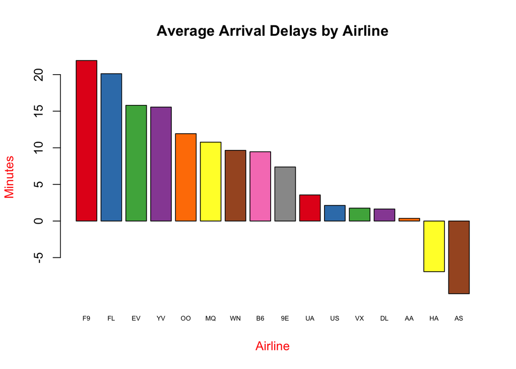

```r
barplot(sort(arr_delay_by_airline, decreasing = TRUE), xlab="Airline", col.lab = "red", ylab="Minutes", col=color, main= "Average Arrival Delays by Airline", cex.names = 0.53)
```

### Airline with the Highest Average Arrival Delay

F9 airline has the highest average arrival delay.

### Airline with the Lowest Average Arrival Delay

AS airline has the lowest average arrival delay.

### Are there airlines that have negative average delay?

Yes, there are two airlines: AS, HA.

# Air Gain

```r
nyc$airgain <- c(nyc$dep_delay - nyc$arr_delay)
```

### Air Gain Statistics

```r
round(mean(nyc$airgain, na.rm=TRUE), 2)
max(nyc$airgain, na.rm=TRUE)
min(nyc$airgain, na.rm=TRUE)
```

[output not shown]

The average time gained is 5.6597789 minutes. The most time gained on a single flight is 109 minutes. The least time gained on a single flight is -196 minutes.

### Air-Time Gained By Month

```r
# Use function tapply
airgain_by_distance <- round(tapply(nyc$airgain, nyc$month, mean,  na.rm=TRUE), 2)

airgain_by_distance
```

```
##     1     2     3     4     5     6     7     8     9    10    11    12
##  3.86  5.15  7.36  2.67  9.37  4.24  4.81  6.53 10.65  6.40  4.96  1.61
```

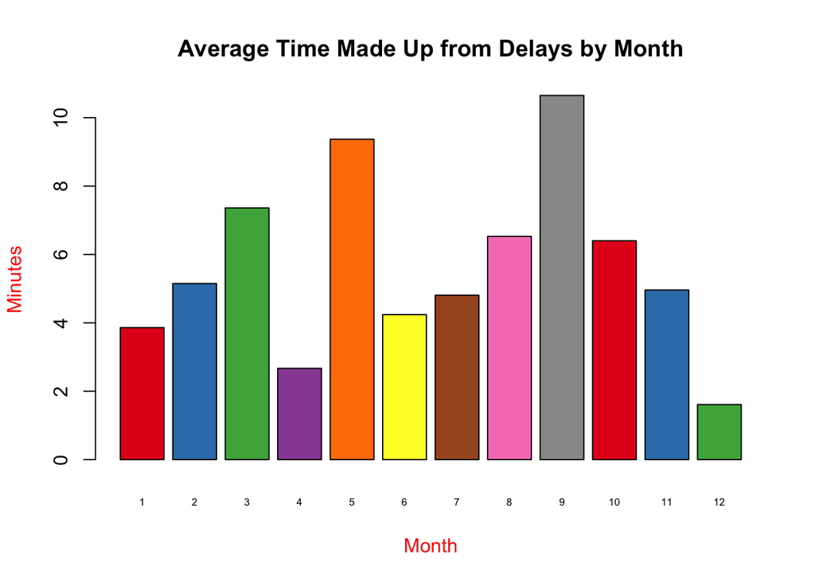

```r
barplot(airgain_by_distance, xlab="Month", col.lab = "red", ylab="Minutes", col=color, main= "Average Time Made Up from Delays by Month", cex.names = 0.53)
```

### Air-Time Gained by Origin Airport

```r
# Use function tapply
airgain_by_origin <- round(tapply(nyc$airgain, nyc$origin, mean,  na.rm=TRUE), 2)

airgain_by_origin
```

```
##  EWR  JFK  LGA
## 5.90 6.47 4.50
```

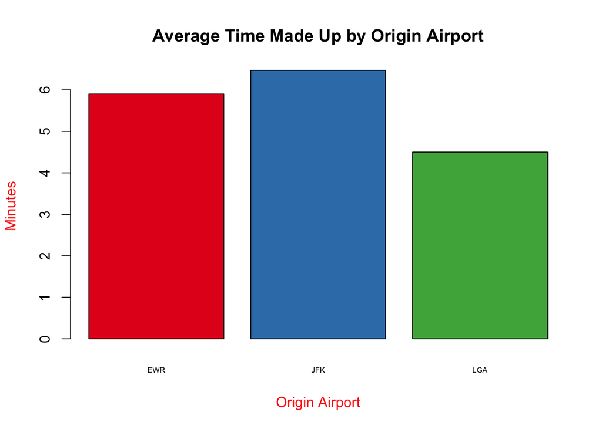

```r
barplot(airgain_by_origin, xlab="Origin Airport", col.lab = "red", ylab="Minutes", col=color, main= "Average Time Made Up by Origin Airport", cex.names = 0.53)
```

### Do airlines actually gain any time when in air on average?

Yes, airlines gain on average 5.66 minutes on average.

### Average Airgain for Airlines

```r
# Use function tapply
airgain_by_airline <- round(tapply(nyc$airgain, nyc$carrier, mean,  na.rm=TRUE), 2)

airgain_by_airline
```

```
##    9E    AA    AS    B6    DL    EV    F9    FL    HA    MQ    OO    UA    US
##  9.06  8.20 15.76  3.51  7.58  4.04 -1.72 -1.51 11.82 -0.33  0.66  8.46  1.62
##    VX    WN    YV
## 10.99  8.01  3.34
```

### Which airline made up the most amount of time while in air?

AS made up the most time while in air by 15.76 minutes on average.

### Which airline made up the least amount of time while in air?

F9 made up the least time while in air by -1.72 minutes on average.

### Airgain by Airline

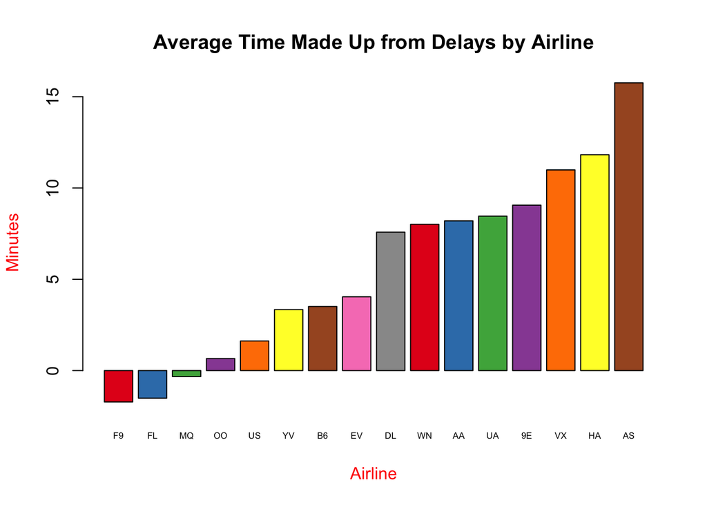

```r
barplot(sort(airgain_by_airline, ), xlab="Airline", col.lab = "red", ylab="Minutes", col=color, main= "Average Time Made Up from Delays by Airline", cex.names = 0.53)
```